# Intuition behind local FDR

Author

[Michael Love](http://mikelove.github.io)

In a previous section, we looked at *adjusting* p-values to define sets with bounds on the family-wise error or false discovery rates. Here I want to show the idea behind a related method called *local FDR* calculation. A nice description of this framework is presented in the paper, [Large-Scale simultaneous hypothesis testing](http://www.tandfonline.com/doi/abs/10.1198/016214504000000089) by Bradley Efron. There is also an R package implementing the methods, which is the [locfdr](https://cran.r-project.org/web/packages/locfdr/index.html) package on CRAN.

Here, I will use entirely simulated data, as I want to show a simple case of how we might estimate the local FDR. Suppose we have 20k tests of some genomic assay, and we have 10 individuals in 2 groups. For 80% of the tests, there is no difference between the groups, but for 20% of the tests, there is a difference, and I will construct the simulation such that the differences are all *positive*. Below I construct simulated data according to this paradigm, and then I use a t-test to produce t-statistics.

```r
n <- 10
m <- 20000
betas <- c(rep(0,.8*m),sort(runif(.2*m,0,2)))
diff <- rep(c(FALSE,TRUE),c(.8,.2)*m)
x <- rep(0:1,each=n)
f <- factor(x)
library(genefilter)
mu <- outer(betas, x)
y <- matrix(rnorm(m * 2 * n, mean=mu), nrow=m)
t <- rowttests(y, f)
```

Small note: the `rowttests` function provides test statistics that are the opposite sign as many other methods (e.g. `lm` and most other Bioconductor packages), so we flip the sign of the statistic so it corresponds to a difference of the group x=1 relative to group x=0. We do the same for the difference in means `dm`, and we define a factor `diff` which tells us whether there is a true difference greater than 0.

```r
library(magrittr)
t$statistic %<>% (function(x) -1 * x)
t$dm %<>% (function(x) -1 * x)
t$diff <- factor(diff, levels=c(TRUE,FALSE))
```

Here I plot the p-values for all 20,000 tests. On the -log10 scale, you can see the enrichment in small p-values for the true alternative hypotheses at the end of the list of 20,000.

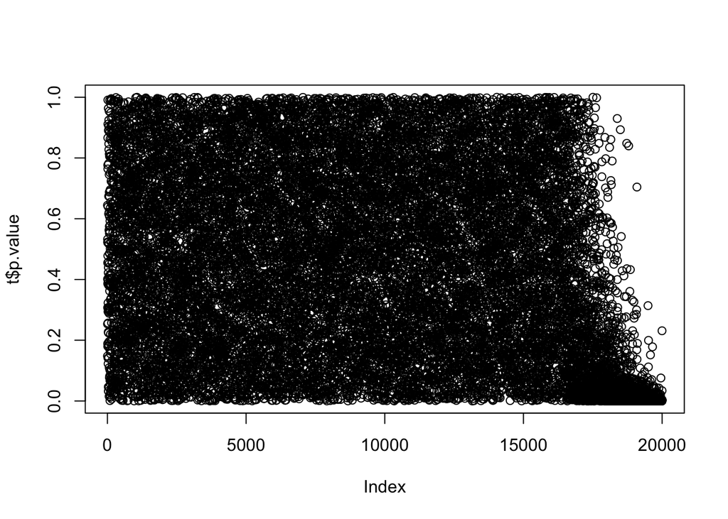

```r
plot(t$p.value)
```

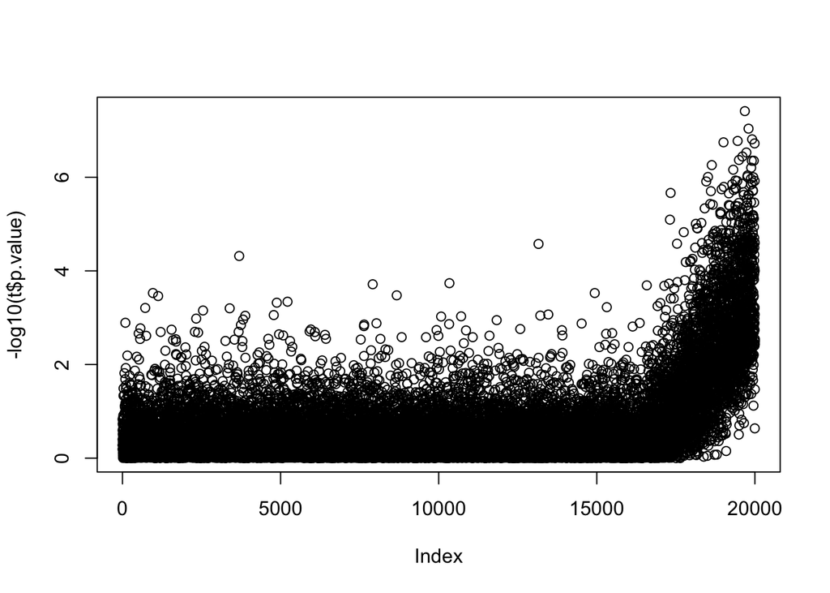

```r
plot(-log10(t$p.value))
```

Additionally, we can see the set of alternative hypotheses in a histogram of p-values. We draw a horizontal line using the known proportion of nulls, $\pi_0 = 0.8$.

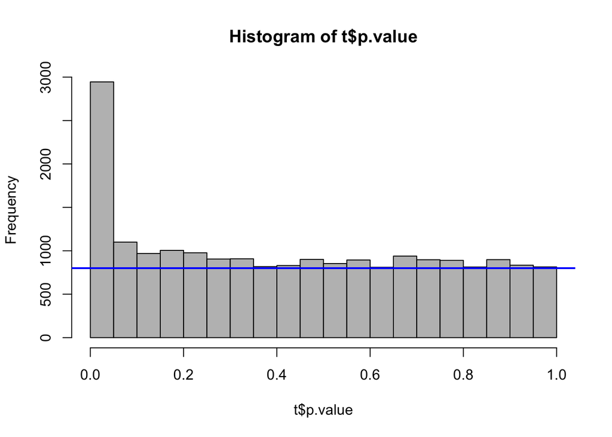

```r
hist(t$p.value, col="grey", breaks=0:20/20)
abline(h=.8*m/20, col="blue", lwd=2)
```

However, aside from looking at the p-values, we could look at the t-statistics alone. Because we used simulation, we can color the tests according to belonging to the set of null or alternative hypotheses. Note that, we simulated positive differences between the two groups, so the t-statistics for the alternative hypotheses form a right tail for the total distribution.

The basic idea of local FDR is that, we might try to estimate the null distribution from the total distribution. Then we could say for a given observed t-statistic, the ratio of blue in a vertical slice is the expected proportion of false discoveries for nearby t-statistics (and so “local”). In the general case, we will not have strictly positive differences and so there is quite a lot of complex statistical methods which can help to estimate the null distribution from the center of a distribution of mixed null and alternative test statistics. See Section 3, “Estimating the empirical null distribution”, of the paper linked above.

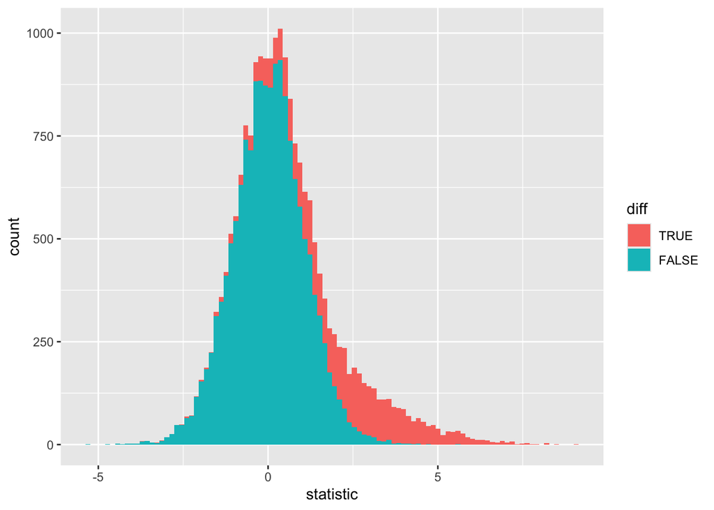

```r
library(ggplot2)
ggplot(t, aes(x=statistic,fill=diff)) + geom_histogram(bins=100)
```

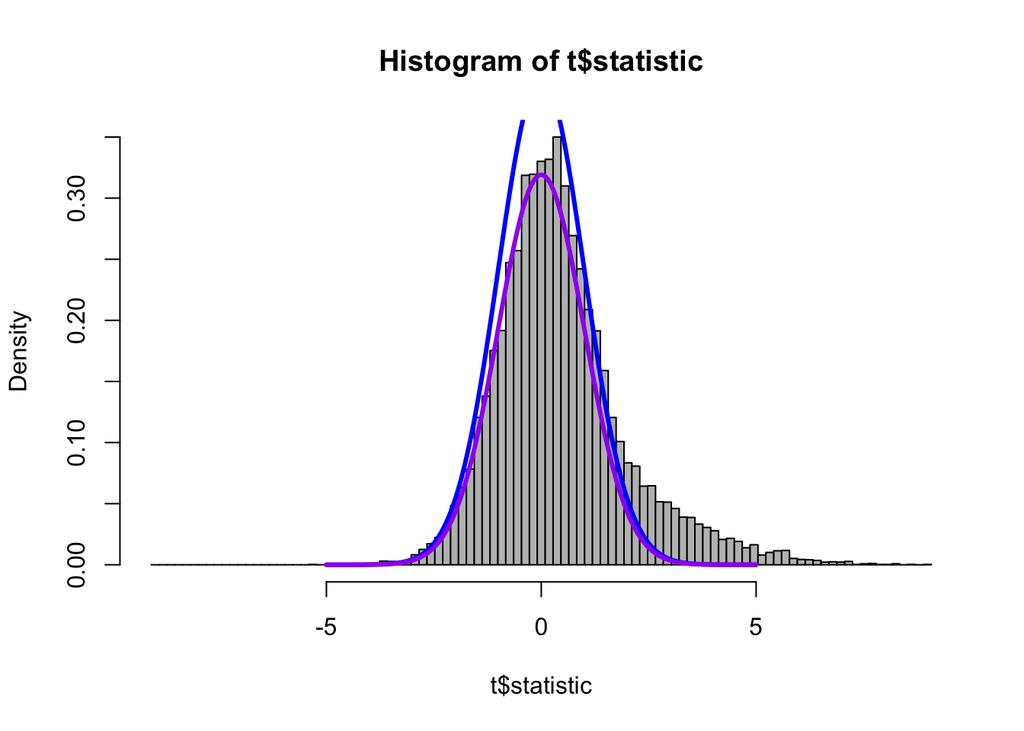

```r
max.t <- max(abs(t$statistic))
brks <- seq(from=-max.t, max.t, length=100)
h <- hist(t$statistic, breaks=brks, col="grey", freq=FALSE)
pi0 <- .8
s <- seq(from=-5,to=5,length=200)
lines(s, dnorm(s), col="blue", lwd=3)
lines(s, pi0*dnorm(s), col="purple", lwd=3)
```

We can try to estimate $\pi_0$ by looking at the left side of the distribution. For example, we observe a certain set of counts along bins of t-statistics, and we can plot the expected counts if all of the hypotheses were null.

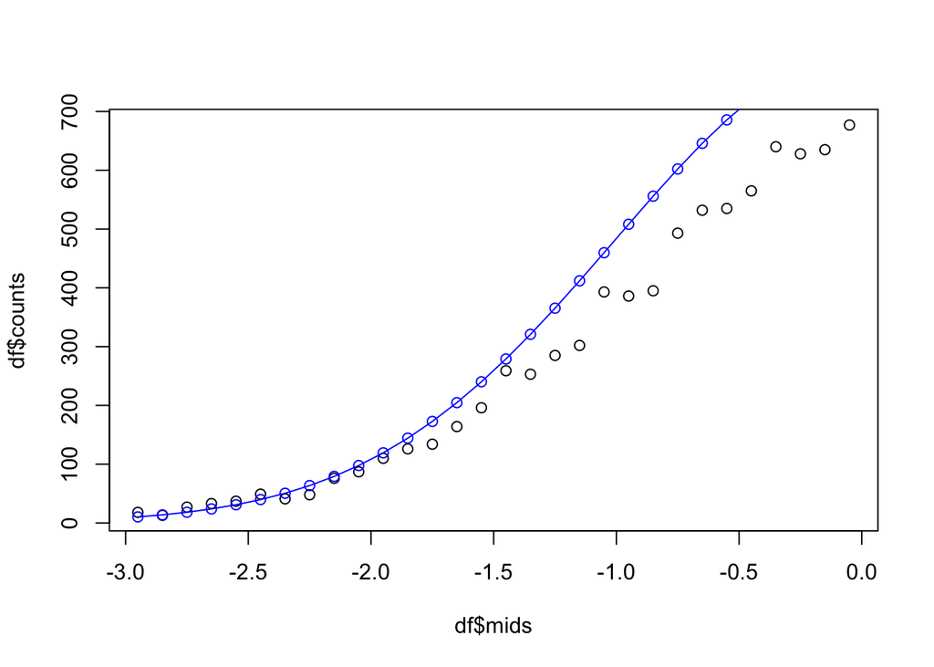

```r
delta <- 0.1
brks <- seq(from=-20, to=20, by=delta)
h <- hist(t$statistic, breaks=brks, plot=FALSE)
df <- data.frame(mids=h$mids, counts=h$counts, density=h$density)
df <- df[df$mids > -3 & df$mids < 0,]
plot(df$mids, df$counts)
brks <- seq(from=-3, to=0, by=delta)
expected <- sapply(seq_len(length(brks)-1), function(i) pnorm(brks[i+1]) - pnorm(brks[i]))
points(df$mids, m*expected, col="blue", type="o")
```

Since we are working with counts, we do a bit better by taking the square root, which helps with variance stabilization. We can then try to fit a line to the observed counts over the expected counts after root transformation. We then estimate $\pi_0$ as the slope of this line squared. Our estimate is fairly close to the true value of 0.8 (80% hypotheses are null).

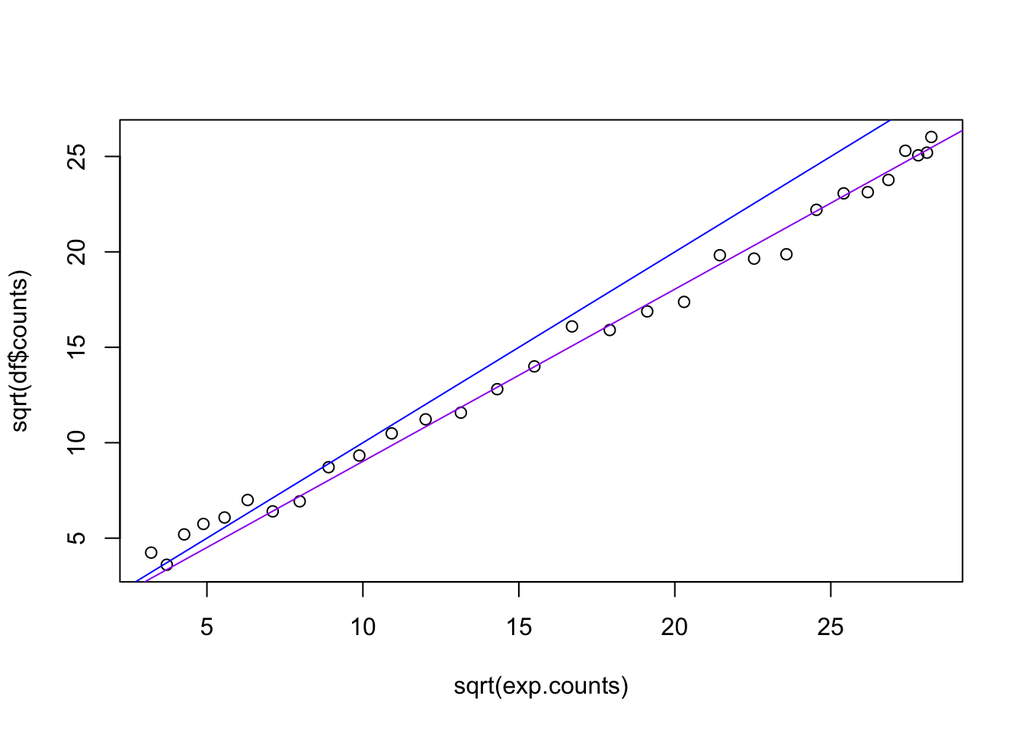

```r
exp.counts <- m * expected
plot(sqrt(exp.counts), sqrt(df$counts))
fit <- lm(sqrt(df$counts) ~ 0 + sqrt(exp.counts))
abline(0,1, col="blue")
abline(fit, col="purple")
```

```r
pi0.hat <- coef(fit)[1]^2
pi0.hat
```

```
sqrt(exp.counts)
       0.8143407
```

We can then plot the observed counts of t-statistics on the left side of the distribution with our new curve:

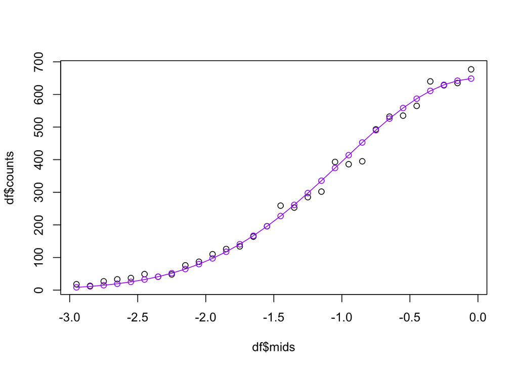

```r
plot(df$mids, df$counts)
points(df$mids, m*pi0.hat*expected, col="purple", type="o")
```

Finally, we plot the distribution on the right side, and put a smooth line with the `lowess` function.

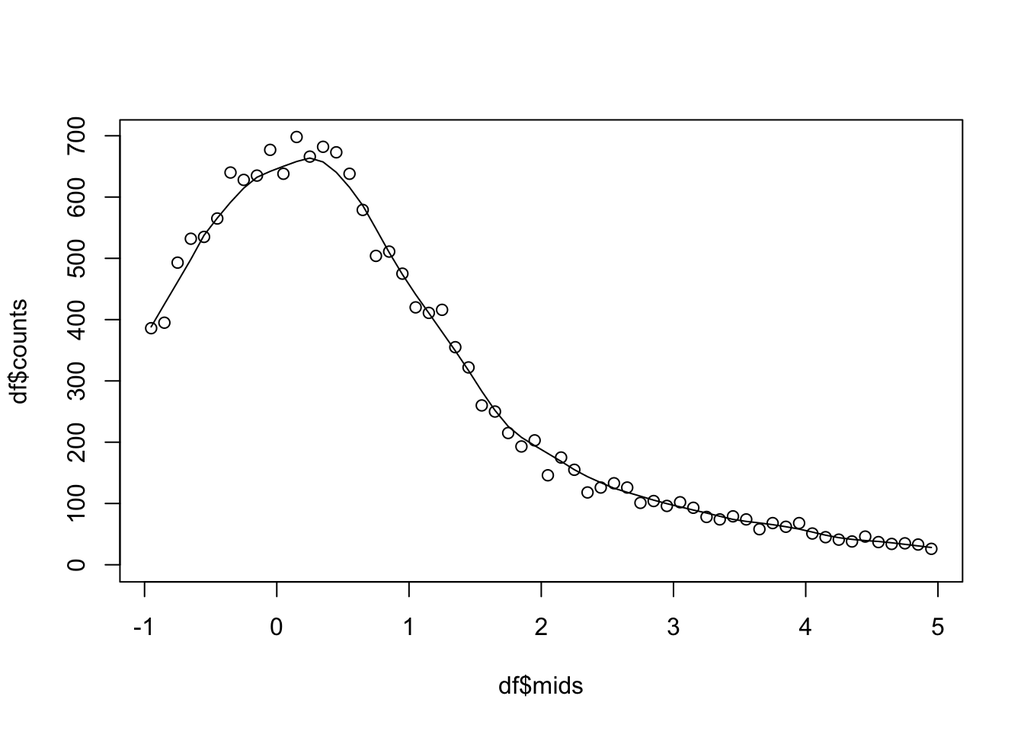

```r
df <- data.frame(mids=h$mids, counts=h$counts, density=h$density)
df <- df[df$mids > -1 & df$mids < 5,]
plot(df$mids, df$counts, ylim=c(0,max(df$counts)))
lines(lowess(df$counts ~ df$mids, f=.15))
```

When we add the estimated scaled density for the null hypotheses, we see something similar to the histogram above, where we colored the stacked bars according to whether they belonged to null or alternative sets. Here we could estimate the local FDR for a given t-statistic using the ratio of the purple line out of the black line.

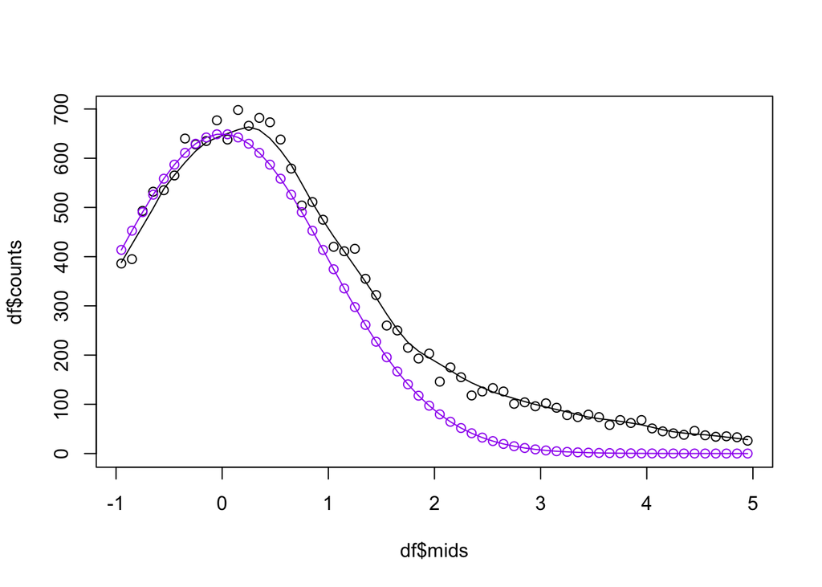

```r
plot(df$mids, df$counts, ylim=c(0,max(df$counts)))
lines(lowess(df$counts ~ df$mids, f=.15))
brks <- seq(from=-1, to=5, by=delta)
expected <- sapply(seq_len(length(brks)-1), function(i) pnorm(brks[i+1]) - pnorm(brks[i]))
points(df$mids, m*pi0.hat*expected, col="purple", type="o")
```

However, note that these steps we have applied here are very rough, and mostly useful for demonstration of the idea. For practical analysis purposes you should read and use the links above for the local FDR paper and [locfdr](https://cran.r-project.org/web/packages/locfdr/index.html) package.